# Assignment2_DH

Danni Harper

March 5, 2018

```r
library(tidyverse)
```

```r
gen.mod <- function(n = 100, b0 = 2, b1 = 3, sd.err = 1) {
    predictor <- runif(n) - 1
    response <- b0 + b1 * predictor + rnorm(n, mean = 0, sd = sd.err)
    return(data.frame(response = response, predictor = predictor))
}
```

Creating a variety of different values for sample size (n), slope (b1) and standard error. Then putting these values into a data frame

```r
n.times <- 1:10
n <- c(25, 75, 150)
b1 <- c(0.5, 1, 3, 4.5)
sd.err <- c(0.1, 0.5, 1, 3.5)

values.df <- expand.grid(n.times = n.times, n = n, b1 = b1, sd.err = sd.err)
```

Using the data frame with the variable values, input these values into the function and then create a model (mod1) that will result in the estimation of t-values for further steps in the question.

```r
for (i in 1:length(values.df$n.times)) {
    tmp.df <- gen.mod(n = values.df$n[i], b0 = 2, b1 = values.df$b1[i], sd.err = values.df$sd.err[i])
    mod1 <- lm(response ~ predictor, data = tmp.df)
    values.df$tvalue[i] <- summary(mod1)$coefficients["predictor", "t value"]
}

values.df$n <- factor(values.df$n)
values.df$b1 <- factor(values.df$b1)
values.df$sd.err <- factor(values.df$sd.err)
```

Plot of t-values for different slopes

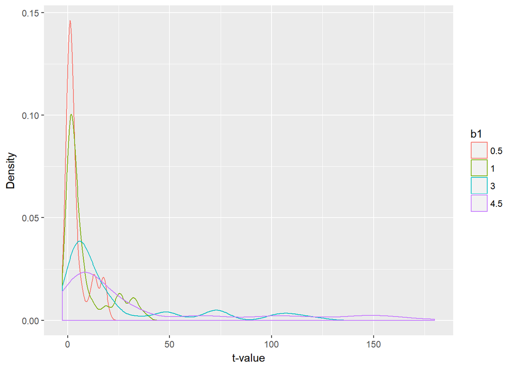

```r
ggplot(data = values.df, aes(tvalue, group = b1, col = b1))+
  geom_density() +
  xlab("t-value") +
  ylab("Density")
```

Plot of t-values for different sample sizes

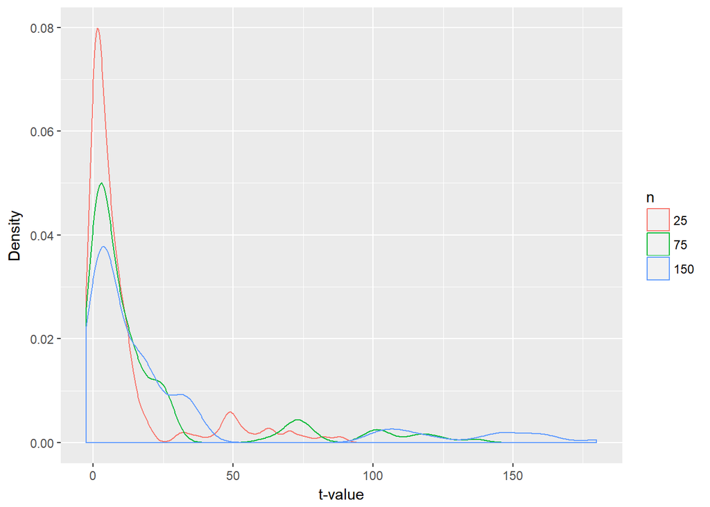

```r
ggplot(data = values.df, aes(tvalue, group = n, col = n))+
  geom_density() +
  xlab("t-value") +
  ylab("Density")
```

Plot of t-values for different standard errors

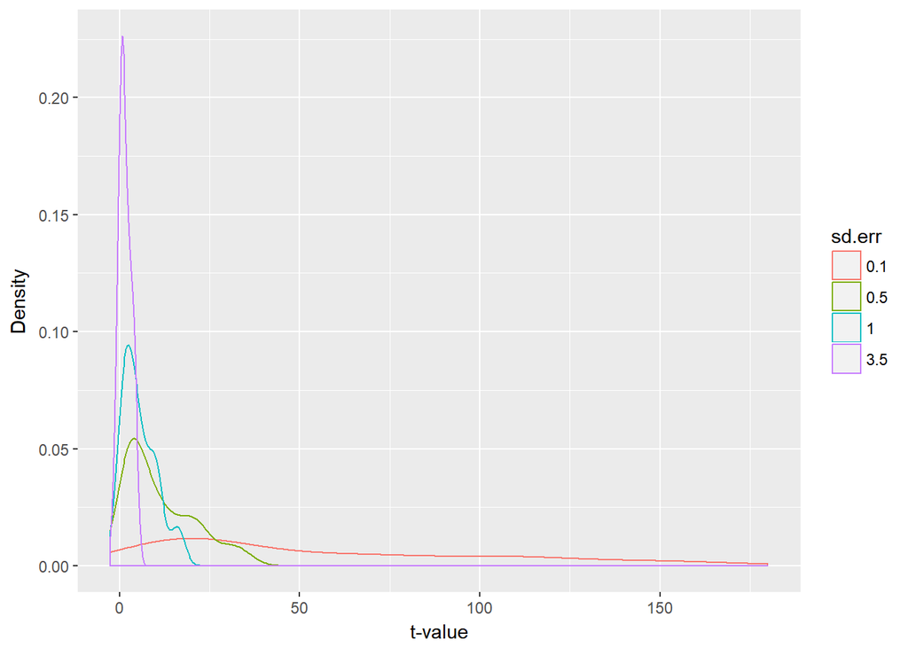

```r
ggplot(data = values.df, aes(tvalue, group = sd.err, col = sd.err))+
  geom_density() +
  xlab("t-value") +
  ylab("Density")
```

Using the same steps as above, created a function using a set b0 of zero (no effect) and a sample size (n) of 100. This time looking for estimation of p-value rather than t-value

```r
gen.mod2 <- function(n = 100, b0 = 0, b1 = 0, sd.err = 1) {
    predictor <- runif(n) - 0.5
    response <- b0 + b1 * predictor + rnorm(n, mean = 0, sd = sd.err)
    return(data.frame(response = response, predictor = predictor))
}
```

```r
n.times <- 1:2000
n <- c(100)
b1 <- c(0)
sd.err <- c(0.1,1, 2.5, 4)

values.df2 <- expand.grid(n.times = n.times, n = n, b1 = b1, sd.err = sd.err)
```

```r
for (i in 1:length(values.df2$n.times)) {
    tmp.df2 <- gen.mod2(n = values.df2$n[i], b0 = 0, b1 = values.df2$b1[i], sd.err = values.df2$sd.err[i])
    mod2 <- lm(response ~ predictor, data = tmp.df2)
    values.df2$pvalue[i] <- summary(mod2)$coefficients["predictor", "Pr(>|t|)"]
}

values.df2$n <- factor(values.df2$n)
values.df2$b1 <- factor(values.df2$b1)
values.df2$sd.err <- factor(values.df2$sd.err)
```

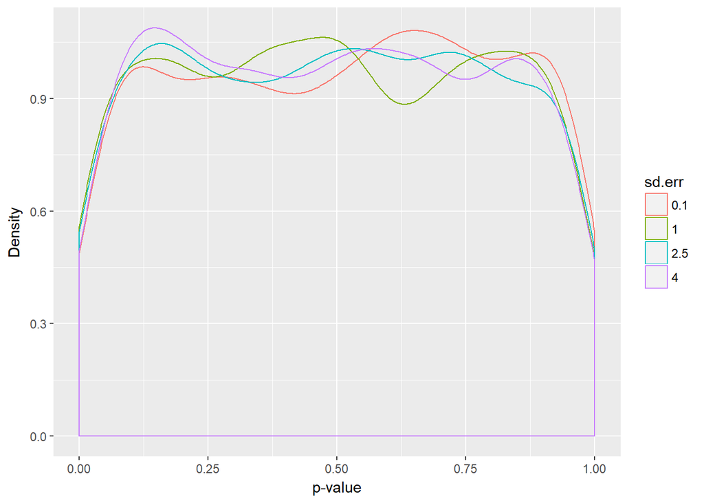

```r
ggplot(data = values.df2, aes(pvalue, group = sd.err, col = sd.err))+
  geom_density() +
  xlab("p-value") +
  ylab("Density")
```

```r
test.sub <- subset(values.df2, sd.err == 5)

with(test.sub, table(pvalue <= 0.05))/length(test.sub$pvalue)
```

```
## numeric(0)
```

Plot showing the different distributions of p-values for different standard errors.

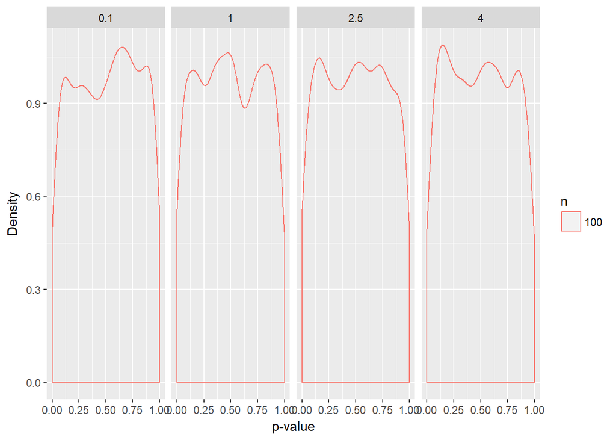

```r
ggplot(data = values.df2, aes(pvalue, group = n, col = n))+
  geom_density() +
  xlab("p-value") +
  ylab("Density") +
  facet_grid(~sd.err)
```